# Microarray case study - 203.305 Lab1

Pierre-Yves Dupont

4 October 2016

# 1 Introduction

The following case study has been developed to illustrate the merits of microarray analysis as a hypothesis-generating tool. By working through this exercise you will learn how to complete a microarray analysis from start to finish. This process involves converting raw data produced by microarray scanners into lists of differentially expressed genes and eventually arriving at biological interpretations of these lists.

All analyses will be carried out with the free statistics and graphics software R (R Development Core Team 2008) and the software package *limma* which implements mathematical functions for the analysis of two color microarrays (Smyth 2005). Using R has two major advantages: first, it is available to everyone at no cost and second, it provides a very flexible framework for microarray analyses. In this module, *ready-to-execute R code* will be provided, since its purpose is not the teaching of programming in R but a demonstration of the utility of R for microarray analysis. Despite providing the code we encourage students to familiarize themselves with R and to decipher the meaning of our scripts.

This case study has been adapted from a published microarray experiment (Schmidt et al. 2005). The data were part of herbivory study carried out to compare the defense responses of two solanaceous plants, *Nicotiana attenuata* and *Solanum nigrum*, to attack by shared herbivores (here *Manduca sexta*). In that study, cDNA from both plant species had been hybridized to a cDNA microarray representing 15,264 *Solanum tuberosum* unigenes (the *potato chip*). *S. tuberosum*, the potato plant, is also a member of the nightshade family (Solanaceae). Thus, micorarrays developed for the potato plant can be used to study species in the same plant family given appropriate caution and controls.

For this case study, four treatments of the original experiment were selected (figure 1), consisting of plants either exposed or not exposed to one day of herbivore feeding.

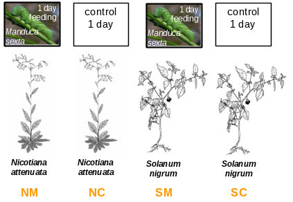

**Figure1: Experimental set up.** The experiment consisted of four treatments resulting four sources of RNA: NM – *N. attenuata* attacked by *M. sexta* for 1 day. NC – *N. attenuata* unattacked for 1 day. SM – *S. nigrum* attacked by *M. sexta* for 1 day. SC – *S. nigrum* unattacked for 1 day.

The module consists of two parts. In the first part, you will determine which genes are up- and down-regulated in each species through a guided step by step execution of an R script. In particular, we will explain how to pre-process and normalize the raw data and how to apply statistical procedures to these transformed data to call differentially expressed genes. We will also introduce graphical tools frequently used in presentation and publications of microarray studies (global gene expression). The second part focuses on the biological interpretation of the results through R scripts that allow enrichment tests of gene sets (gene ontologies) and a guide to online resources which allow you to research differentially expressed genes of your choice.

You will be working on iMacs in the physics lab (SC5.15). Ideally you work on the same computer in both labs as you will be using files created in lab 1 for lab 2. Log on to the Bioinformatics account (password: IMBSTeaching). R and the required libraries are installed. You will also have access to Excel. All data are saved in the ‘case study’ folder in the Bioinformatics device. Before you begin, drag and drop the complete ‘case study’ folder to your desktop. Files that you generate during the analysis will be written into the same folder. Data contained in the case study folder include:

- Raw data: 2450.gpr, 2455.gpr, 2460.gpr, 2465.gpr, 2470.gpr, 2475.gpr
- Scripts: case study script.R, gse test.R
- Supporting files: targetsherb.txt, find.txt, potato_gomatrix.txt
- Graphs: MA plots folder, density plots folder, box plots folder, spatial plots folder

# 2 First step in R

R is a freely available statistics and graphics software that is widely used in bioinformatics. The main advantage is that scientists themselves constantly add to it by programming new software packages that run in the R environment and that R is constantly updated too. As a rule of thumb there is a package for any genome analysis job you would like to get done. To be able to take advantage of the wealth of R-based packages you need to familiarize yourself with some basic R procedures and not be afraid to use a command line interface.

To get started, launch RStudio . Commands can be typed directly into the *Console* or alternatively in the *Editor*. The latter has the advantage that a collection of commands (called a *script*) can be saved and thus re-run and modified later. To execute commands from the editor, highlight the command and click CTRL+Return. Apart from commands, a script often contains comments of various kinds. Comments are preceded by the # sign which prevents R to try and execute them.

## 2.1 Exercise 1

There are quite a few data sets built into R. One of them is Student’s sleep data. In this experiment, the intention was to test if two different drugs would differ in their effect of prolonging sleep. Both drugs were given to 10 patients and the hours of extended sleep recorded for each. The data set consists of two columns: *extra* lists the hours of extra sleep each person had and *group* is either 1 or 2 depending on what drug was given. Do the exercise below by typing commands in the R console window and once you are done, answer the question: Did the two drugs have a different effect?

```r
#have a look at the sleep data by typing ‘sleep’ in the ‘R console’
sleep

#next, explore and analyse the ‘sleep’ data with the following R commands:
#display dimensions of the object
dim(sleep)

#display the minimum value for drug one, indexing elements in R is done with square
#brackets, rows #are indexed before columns, e.g. [1:10,1] means the first ten rows
#and the first column
min(sleep[1:10,1])

#display the maximum value for drug two
max(sleep[11:20,1])

#calculate mean for drug one and median for drug two
mean(sleep[1:10,1])
median(sleep[11:20,1])

#calculate the standard deviation for drug one and display statistical summary
#for drug two
sd(sleep[1:10,1])
summary(sleep[11:20,1])

#order the data frame by column ‘extra’
sleep[order(sleep$extra),]

# display a box plot of the data
plot(extra ~ group, data = sleep)

#perform a paired t-test on the data
t.test(extra ~ group, data = sleep, paired = TRUE)

#for help on any function use ‘help(function)’, for example for help on the t.test
#function type:
help(t.test)
```

## 2.2 Exercise 2

With R you can also create data sets, either by defining vectors, matrices and lists that contain your data or by reading your data from a file. Follow the commands below.

```r
# create a data vector x with specified elements and a data vector y with elements 1 to 5
# the display the newly created vectors x and y
x<-c(1,2,4,8,16 )
y<-c(1:5)
x
y

# combine both vectors into a matrix
# display the new matrix
mat<-cbind(x,y)
mat

# another important feature of R are loops, e.g. the “for loop” has the general structure
# “for (i=1:x) {do something}”
# for example, create a new vector that adds 1 to each element of vector x;
# the command to be repeated a number of times is placed in curly brackets
a <- NULL
for (i in 1:length(x))   { a <- c (a,x[i]+1) }
# display newly created vector a
a
```

Here is a list of other frequently used commands (for your information only).

```r
getwd() # show the current working directory
setwd('directory') # allow you to set the current working directory
list.files() # list all file in the working directory
ls() # list all objects in the workspace
rm() #remove an object from the workspace
data <- read.table(data.txt, header=TRUE) # read data from file
data <- read.table(file("clipboard"),header=TRUE) # read data from clipboard
save.image(file = "data.RData") #save all objects in workspace to a file
load(file = "data.RData") #load a previously saved R workspace back into R
```

# 3 Step by step Microarray analysis

## 3.1 Setup

1. Create a RStudio project: *File* -> *New Project* -> *Existing directory*.
2. Set the working directory: In the bottom right window: *Files* -> *More* -> *Set as working directory*. Files that you produce during the analysis (text files, graphics) will be saved to your working directory.
3. Open the script file **case study script.R**. The R script contains *commands* (without the # in front) and *comments* (with the # in front).
4. Load the *limma* package: in the console (bottom left window):

```r
library(limma)
```

## 3.2 Inspect one of the raw data files in Excel.

Open one of the raw data files (.gpr, generated by the image analysis software) in Excel and look at the raw data. Each file represents one array. It contains foreground and background intensities for the red (F635, B635) and the green (F532, B532) channel for each spot on the array plus annotation to unambiguously identify each spot. The foreground is an overall measure of the intensity of the spot while the background is a measure of the ambient signal. Background fluorescence can arise from many sources, such as non-specific binding of labelled sample to the array surface, processing effects such as deposits left after the wash stage or optical noise from the scanner. Most image analysis programs return local background intensities, obtained from the mean or median of the pixel intensity values surrounding each spot.

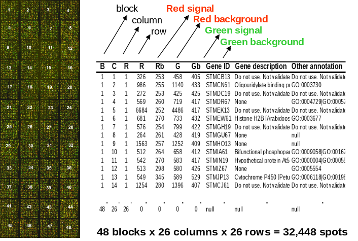

**Figure 3: Spatial image and simplified version of a raw data file generated by a microarray scanner.** Left panel: Spatial image of overlay of red and green channel of the potato cDNA array. The grid consists of 48 blocks each of which consists of 26 columns and 26 rows amounting to a total of 32,448 spots. Not all spots contain DNA. Right panel: A ‘.gpr’ file is generated for each array. It contains the following main information for each spot: coordinates on the array, mean and median foreground and background signal intensities of the red (wave length 635) and the green (wave length 532) channel, gene identifier, gene description and other annotation.

## 3.3 Complete the data and design section.

Follow the instructions in the script. First, tell limma in which files it finds the raw data by reading in a *targets* file (function *readTargets*).

```r
#The txt file "targetsherb.txt" contains informantion about what samples
#have been labeled with cy3 and cy5 on each array and in which
#file the data for each array is stored. With the command below the content of this
#file is being stored in an R object called 'targets'.
targets <- readTargets("targetsherb.txt", row.names="Name")
targets
```

```
##             Slide     Name Cy3 Cy5 FileName
## NMvsNC_1 12559679 NMvsNC_1  NM   C 2450.gpr
## NMvsNC_2 12559023 NMvsNC_2  NM   C 2455.gpr
## NMvsNC_3 12559422 NMvsNC_3  NM   C 2460.gpr
## SMvsSC_1 12555026 SMvsSC_1  SM   C 2465.gpr
## SMvsSC_2 12554762 SMvsSC_2  SM   C 2470.gpr
## SMvsSC_3 12559333 SMvsSC_3  SM   C 2475.gpr
```

This text output of the table can be seen like:

|  | Slide | Name | Cy3 | Cy5 | FileName |
| --- | --- | --- | --- | --- | --- |
| NMvsNC_1 | 12559679 | NMvsNC_1 | NM | C | 2450.gpr |
| NMvsNC_2 | 12559023 | NMvsNC_2 | NM | C | 2455.gpr |
| NMvsNC_3 | 12559422 | NMvsNC_3 | NM | C | 2460.gpr |
| SMvsSC_1 | 12555026 | SMvsSC_1 | SM | C | 2465.gpr |
| SMvsSC_2 | 12554762 | SMvsSC_2 | SM | C | 2470.gpr |
| SMvsSC_3 | 12559333 | SMvsSC_3 | SM | C | 2475.gpr |

Then, read in the data themselves (the function *read.maimages* will read in mean foreground and median background intensities of the red and green signals of each array).

```r
#read in array data and store in an object called 'RG' for RedGreen
RG <- read.maimages(targets$FileName,
                    source="genepix",
                    annotation=c("Block", "Row", "Column", "Name", "Clone_name", "ID", "TA", "GO"),
                    other.columns="Flags",wt.fun=wtflags(0))
```

```
## Read 2450.gpr
## Read 2455.gpr
## Read 2460.gpr
## Read 2465.gpr
## Read 2470.gpr
## Read 2475.gpr
```

```r
#Check the data that you just loaded
dim(RG)# tells you the size of the object
RG[1:5,]

#Create the pictures of the 6 microarrays for both channels
imageplot3by2(RG, z="Gb", high="black", low="white")
imageplot3by2(RG, z="Rb", high="black", low="white")
```

Next, set up a design matrix to tell limma which arrays contain data for a particular sample so limma can calculate coefficient for each sample.

```r
#create design matrix
#the design matrix specifies how many different RNA sources will be compared
#so that a coefficient (or ratio) for each RNA source can be calculated
#the first coefficient NM represents the caterpillar-infested tobacco plant
#the second coefficient SM represent the caterpillar-infested nightshade plant

design <- modelMatrix(targets, ref="C")
```

```
## Found unique target names:
##  C NM SM
```

```r
design
```

```
##          NM SM
## NMvsNC_1 -1  0
## NMvsNC_2 -1  0
## NMvsNC_3 -1  0
## SMvsSC_1  0 -1
## SMvsSC_2  0 -1
## SMvsSC_3  0 -1
```

Now, set up a *contrast matrix* that specifies how limma should calculate your comparisons of interest (also called *contrasts*) from the coefficients specified in the design matrix. We are interested in 3 comparisons/contrasts:

1. NM – genes induced by M. sexta in N. attenuata after 1 day of feeding
2. SM – genes induced by M. sexta in S. nigrum after 1 day of feeding
3. NM-SM – genes differentially regulated in N. attenuata and S. nigrum when attacked by M. sexta

```r
#specify contrasts (=comparisons of interest)
#the first two are identical to the coefficients from the design matrix
#in addition to genes induced in tobacco plants (NM) and nightshade plants (SM)
#we are interested in the genes that are induced in one but not the other (NM-SM)

cont.matrix <- makeContrasts(NM, SM, NM-SM, levels=design)
cont.matrix
```

```
##       Contrasts
## Levels NM SM NM - SM
##     NM  1  0       1
##     SM  0  1      -1
```

**Graphs:** Spatial images of red and green background and uncorrected M-values are provided in the folder *spatial plots*. You will notice that the background is not evenly distributed across each slide and that red and green backgrounds for one array sometimes differ.

## 3.4 Background correction.

Microarray data must be background corrected to remove the effects of non-specific binding or spatial heterogeneity across the array. Background correction can be done by different methods. To simply subtract the background from the foreground signal has been found to result in too many false discoveries in the end. *Limma* provides a method called *normexp*. It performs well and results in strictly positive adjusted signal intensities.

```r
#necessary to eliminate unspecific flourescence
#create new object RG.b using the previously created RG object
RG.b <- backgroundCorrect(RG, method="normexp", offset=50)
```

```
## Array 1 corrected
## Array 2 corrected
## Array 3 corrected
## Array 4 corrected
## Array 5 corrected
## Array 6 corrected
## Array 1 corrected
## Array 2 corrected
## Array 3 corrected
## Array 4 corrected
## Array 5 corrected
## Array 6 corrected
```

Look at you new variable and compare it to the old one

```r
RG[1:3,1]
RG.b[1:3,1]
```

## 3.5 Eliminate non-validated spots

Non-validated spots (identified by ID=0) will be excluded from further analysis.

```r
#the 'potato chip' has some spots that were marked by the manufacturer as
#'non-validated' spots and it has been recommended that they are to be
#excluded from the analysis
index <- which(RG.b$genes$ID=="1")
RG.f <- RG.b[index,]
```

```r
#check how the number of genes has dropped by comparing the dimension
#of the RG.b object with that of the RG.f object
dim(RG.b)
dim(RG.f)
```

## 3.6 Transform data

Usually, logarithms to base 2 are taken from the red and green signal intensities of each array. This leads to an even spread of the data across the intensity range, similar variability at most intensity levels and a bell-shaped distribution of intensities. Then, M and A values are calculated, which are defined as follows:

$$\begin{aligned}
M = log_2(Cy_5/Cy_3) = Log_2(Cy_5) - log(Cy_3) \\
A = (log_2(Cy_5) + log_2(Cy_3)) / 2 = \frac{log_2(Cy_5 * Cy_3)}{2}
\end{aligned}$$

```r
#this is done to ensure an even spread of the data and similar variation across all intensities
#the M value (log fold ratio) is defined like this: log2(intensity of the red signal/intensity of the green signal)
#the A value (average log intensities) is defined like this: (log2(intensity of the red signal) + log2(intensity of the green signal))/2.
RG.n <- normalizeWithinArrays(RG.f, method="none")
```

Plot the data to see the effect of the log function on the data distribution.

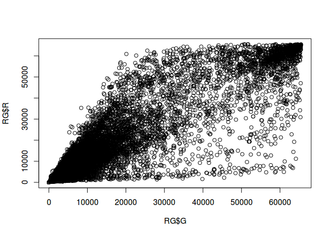

```r
plot(RG$G,RG$R)
```

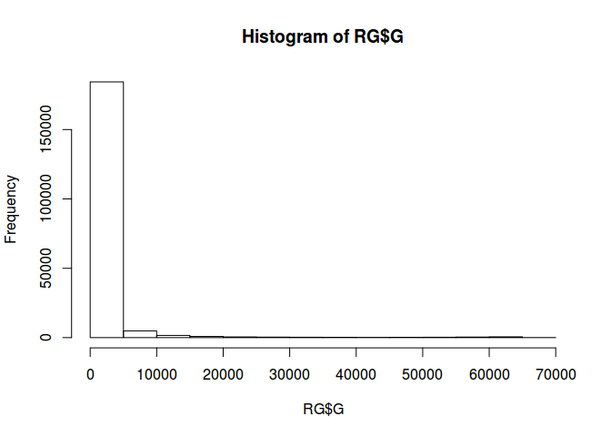

```r
hist(RG$G)
```

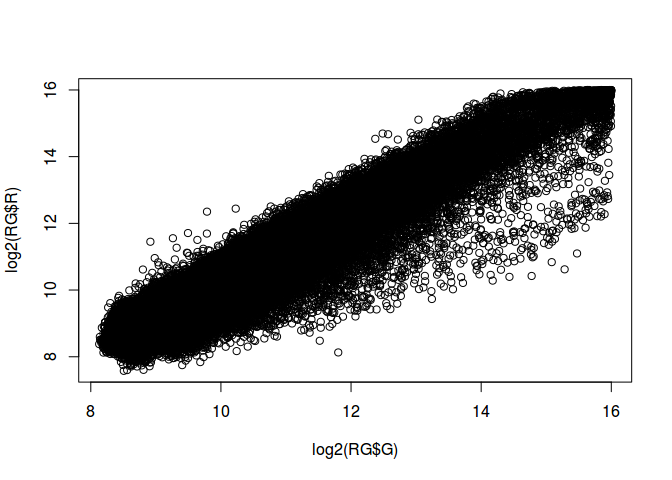

```r
plot(log2(RG$G),log2(RG$R))
```

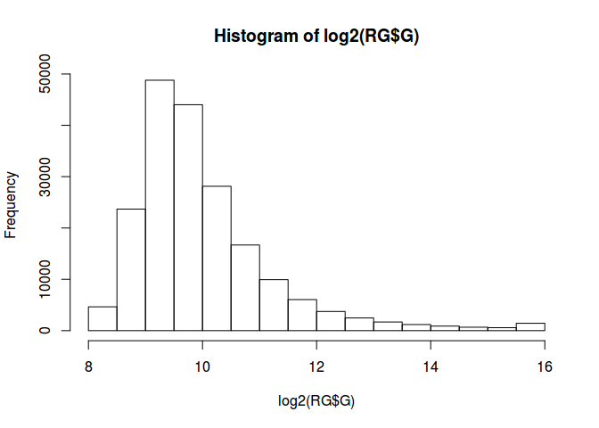

```r
hist(log2(RG$G))
```

Check how $R and $G are gone from the RG.n object and $M and $A have been added to the RG.n object by comparing the first three genes of the first array in objects RG.f and RG.n

```r
RG.f[1:3,1]
RG.n[1:3,1]
```

## 3.7 Within-array normalization

Normalization is required to remove any systematic trends which arise from the microarray technology rather than from differences between the RNA samples hybridized to the array. Within-array normalization is needed to remove bias associated with a) different responses of the green and the red channel and b) intensity differences across different areas of an array (spatial bias). To achieve this, a non-linear regression (*loess*) of the M values against the A values is performed. The normalized M-values are calculated by subtracting the M values fitted on the regression from the raw M values.

**Graphs:** Compare the MA plots for each of the six microarrays before and after within array normalization that are provided in the MA plots folder.

```r
#this is done to remove experimental variability that stems from using two different
#dyes
#fit a non-linear regression (called loess) of the M values to the A values
#to obtain normalized M values the fitted M values will be subtracted from the un-normalized M values
MA <- normalizeWithinArrays(RG.n, method="loess")
```

```r
#check the effect of within array normalization on M and A values
#by looking at the first three genes of the first array in the RG.n object
#and the newly created MA object
RG.n$M[1:3,1]
MA$M[1:3,1]
RG.n$A[1:3,1]
MA$A[1:3,1]
```

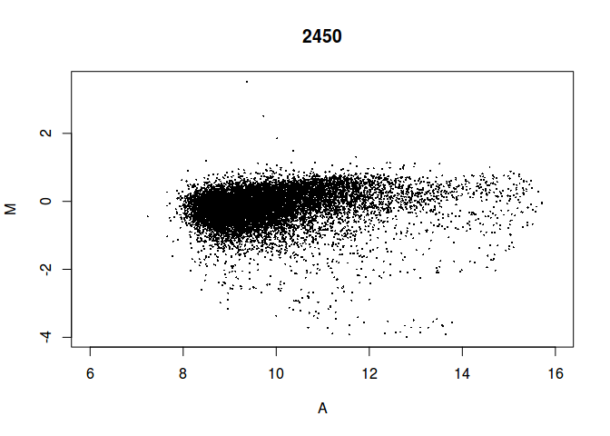

```r
#compare the MA plot before and after lowess normalization
plotMA(RG.n[,1])
```

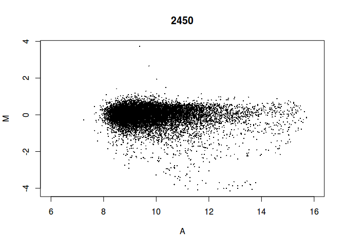

```r
plotMA(MA[,1])
```

## 3.8 Between array normalization

To be able to compare samples hybridized to different arrays, it is necessary to correct for the variability introduced by using multiple arrays. Methods for between-array normalization all assume that variations in the distributions of the M-values between arrays are a result of experimental conditions and do not represent biological variability. A frequently used method is *quantile* normalization. *Quantile* normalization as implemented in *limma* ensures that the red and green intensities have the same empirical distribution across arrays and across channels. It changes both the M and A values when compared to the M and A values obtained after within-array normalization.

```r
#this is done to account for experimental variation that stems from using different
#arrays
#quantile normalization as implemented here equalizes the distributions of the
#red and green signal intensities across all arrays
MA.q <- normalizeBetweenArrays(MA, method="quantile")
```

```r
#check the effect of between array normalization on M and A values
#by looking at the first three genes of the first array in the MA object
#and the newly created MA.q object
MA$M[1:3,1]
MA.q$M[1:3,1]
MA$A[1:3,1]
MA.q$A[1:3,1]
```

Use box-plots to see the effects of the normalization

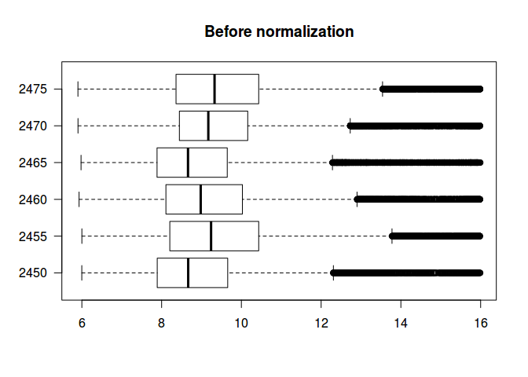

```r
boxplot(MA$A, main="Before normalization", horizontal=TRUE,las=1)
```

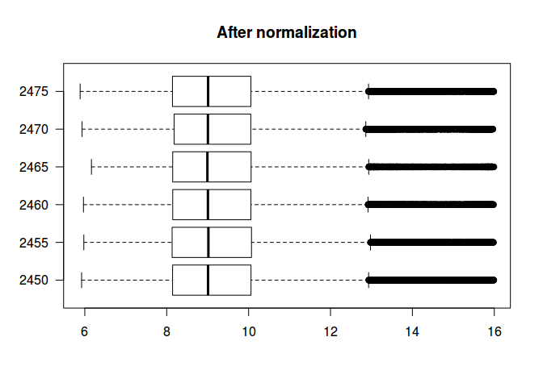

```r
boxplot(MA.q$A, main="After normalization", horizontal=TRUE,las=1)
```

Remark: in a R box-plot, the whiskers are:
$$UpperWhisker = min(max(x), Q_3 + 1.5 * IQR)\\
LowerWhisker = max(min(x), Q_1 – 1.5 * IQR)$$
With IQR being the Inter Quartile Range (aka. the length of the box)

**Graphs:** Compare the box plots of the red intensities before and after between array normalization that are provided in the box plots folder. Also, compare the density plots of the red and green intensities after background correction, after within-array normalization and after between-array normalization that are provided in the density plots folder.

## 3.9 Statistical analysis.

```r
#each gene (clone) has been spotted twice on the array
#in this step the data are sorted by clone name so that duplicate spots
#of the same gene appear in consecutive rows
#this is needed for subsequent spot averaging
index2 <- order(MA.q$genes$"Clone_name")
MA.q <- MA.q[index2,]

#now calculate the average of replicate spots
MA.q.a <- avedups(MA.q, ndups=2, spacing=1) #weighted average
```

```r
#check how the number of spots was halfed by this step by comparing the dimensions
#of the MA.q object with the dimensions of the MA.q.a object
dim(MA.q)
dim(MA.q.a)
```

2. Call function *lmFit*. A linear model is fitted to the expression data for each spot. Expression ratios (=coefficients) are calculated according to the design matrix and stored in object *fit1*.

```r
fit1 <- lmFit(MA.q.a, design)
#check the dimensions of fit1
dim(fit1)

#look at expression coefficients for the first three genes
fit1$coefficients[1:3,]
```

3. Next, call function *contrasts.fit*. Expression ratios (*coefficients*) are calculated for each comparison specified in the contrast matrix.

```r
fit2 <- contrasts.fit(fit1, cont.matrix)
```

```r
#check the dimensions of fit2
dim(fit2)

#look at expression coefficients for the first three genes
#the first two are identical to the expression coefficients in fit1
fit2$coefficients[1:3,]
```

4. Then, call function *eBayes*. With this function, moderated t-statistics, a moderated F-statistic, p-values for both the t- and F-statistics and log odds for differential expression are calculated for each spot. The moderated t-statistics test whether or not log fold expression ratios (M-values) are significantly different from zero (this is done for all 3 comparisons separately). On the other hand, the moderated F-statistic tests if any of the 3 separate M values were significantly different from zero. The F-statistic is an overall test computed from the set of t-statistics for that gene.

```r
fit3 <- eBayes(fit2)
```

Show t-statistics with p-value of differential expression for the first three genes

```r
fit3$t[1:3,]
```

```
##        Contrasts
##                NM        SM    NM - SM
##   2029  -3.103273 -3.824858  0.5102378
##   7437   2.743329  1.744145  0.3010710
##   12845  2.329443  5.084247 -1.9479407
```

```r
fit3$p.value[1:3,]
```

```
##        Contrasts
##                 NM           SM   NM - SM
##   2029  0.01098356 0.0032505870 0.6207837
##   7437  0.01763365 0.1063297133 0.7684455
##   12845 0.03784637 0.0002577223 0.0748757
```

## 3.10 Call differentially expressed genes

Use the *decideTests* function to call differentially expressed genes based on a combination of thresholds for adjusted p-values (0.05) and M values (-0.58 < M < 0.58). Applying the summary function to the *results* object will show you numbers of differentially expressed genes for each of the three comparisons.

```r
#given the log2 scale this includes genes with M>0.58 and M<-0.58
#p-values have been adjusted for multiple testing using the default
#adjustment implemented in 'decideTests': BH (Benjamini-Hochberg adjustment)
log2(1.5)
```

```
## [1] 0.5849625
```

```r
results <- decideTests(fit3, lfc=log2(1.5))
```

For each gene and contrast the ‘results’ object contains either:

| Value | Meaning |
| --- | --- |
| 0 | Not differentially expressed |
| -1 | Down-regulated |
| +1 | Up-regulated |
| NA | No result obtained |

Look at the values for the first 20 genes

```r
results[1:20,]
summary(results)
```

You should obtain the following number of differentially expressed genes:

|  | NM | SM | NM - SM |
| --- | --- | --- | --- |
| -1 | 194 | 175 | 69 |
| 0 | 7306 | 7413 | 7645 |
| 1 | 399 | 311 | 185 |

**Table 1** Numbers of down-regulated (-1), not differentially regulated (0) and up-regulated (+1) genes in each of the three contrasts

## 3.11 Create lists of differentially expressed genes.

Save lists for each of the three comparisons by executing the loop in the following R code.

```r
for (i in 1:3) {
  top <- topTable(fit3, coef=i, n=11243)
  top <- top[order(top$Clone_name),]
  cc <- cbind(top,results[,i])
  a <- names(cc)
  a[15] <- c("test")
  colnames(cc) <- a
  write.table(cc,(paste(i,"_all.txt",sep="")), col.names=NA, sep="\t")
  c <- cbind(top,results[,i])
  a <- names(c)
  a[15] <- c("test")
  colnames(c) <- a
  c_m1 <- c[which(c$test==-1),]
  dim(c_m1)
  write.table(c_m1, paste(i,"_down.txt",sep="") ,sep="\t", col.names=NA)
  c_m1_s <- c_m1$Clone_name
  length(c_m1_s)
  write.table(c_m1_s, paste(i,"_down_s.txt",sep="") , sep="\t", col.names=NA)
  c_p1 <- c[which(c$test==1),]
  dim(c_p1)
  write.table(c_p1, paste(i,"_up.txt",sep="") , sep="\t", col.names=NA)
  c_p1_s <- c_p1$Clone_name
  length(c_p1_s)
  write.table(c_p1_s, paste(i, "_up_s.txt",sep=""), sep="\t", col.names=NA)
}
```

These lists contain annotation information (first eight columns), log fold change (M value), average expression (overall A value), t-statistic, P.value, adjusted P.value, B (log odds of differential expression) and the *expression score* generated by the *decideTests* function (-1,0,+1, NA) for all genes (list 1), down-regulated genes (list 2) and up-regulated genes (list 3).

## 3.12 Create volcano plots.

Save volcano plots for each of the three comparisons/contrasts. Up-, down- and non-regulated genes are depicted in red, green and black, respectively. Volcano plots are a very compact and informative graphical tool to visualize the results of differential gene expression.

```r
#create volcano plots for each of the three contrasts (NM, SM, NM-SM) by running the
#loop below. One of the lists you created in the previous step
#('contrastnr_run1.txt')is being read back into R for this purpose.

for(j in 1:3)
{
  genes <- read.delim(paste(j,"_all.txt",sep=""), header=TRUE, row.names=1)
  dim(genes)
  genes$log.adj.P.Val <- abs(log10(genes$adj.P.Val))
  genes<-na.omit(genes)
  genes.m1 <- genes[genes$test==-1,]
  dim(genes.m1)
  genes.n <- genes[genes$test==0,]
  dim(genes.n)
  genes.p1 <- genes[genes$test==1,]
  dim(genes.p1)

  jpeg(paste(j,"_vp.jpg"),width=600, height=600)
  plot((genes[,9]),(genes[,14]), type="n", xlab="Log Fold Change", ylab="abs Log10(adj.P.value)", cex.axis=1.6, cex.lab=1.6, xlim = c(-5, 5), ylim = c(0,10))
  points((genes.m1[,9]),(genes.m1[,16]), col="green")
  points((genes.n[,9]),(genes.n[,16]), col="black")
  points((genes.p1[,9]),(genes.p1[,16]), col="red")
  abline(v=log2(1.5), lty=3)
  abline(v=-log2(1.5), lty=3)
  abline(h=0)
  abline(v=0)
  abline(h=abs(log10(0.05)), lty=3)
  dev.off()
}
```

Example of Volcano plot:

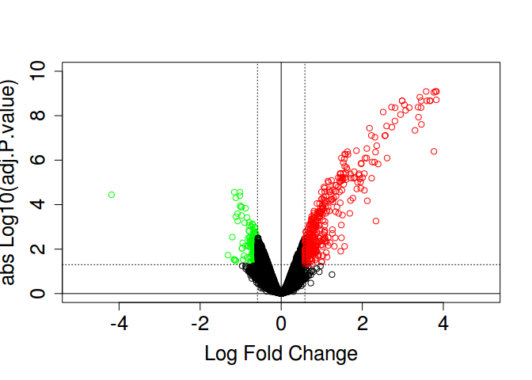

## 3.13 Create Venn diagrams and lists of commonly regulated genes.

### 3.13.1 Venn diagrams

Save Venn diagrams using the limma function ‘VennDiagram’. Venn diagrams graphically depict intersections of lists of differentially expressed genes. Thus they illustrate which genes are commonly regulated in treatments of interest. Save Venn diagrams separately for up- and down regulated genes and compare your results with the numbers in the Venn diagram in figure 4.

Also, create a list with the 120 and 26 commonly up- and down-regulated genes.

```r
#use the 'results' object created previously

jpeg("NMvsSM_up.jpg")
vennDiagram(results[,1:2],include="up")
dev.off()

jpeg("NMvsSM_down.jpg")
vennDiagram(results[,1:2],include="down")
dev.off()
```

**Figure 4: Ven diagram**

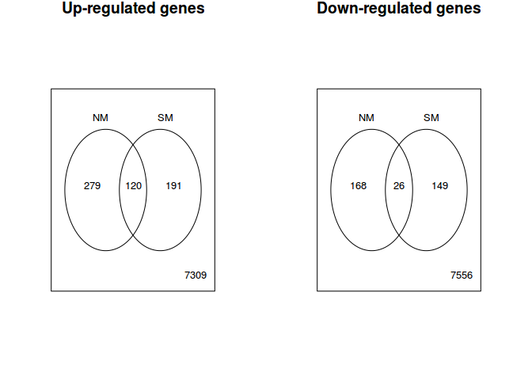

### 3.13.2 Save lists of genes commonly regulated in both treatments

**Down-regulated genes (26 genes)**

Use the 4th list created previously (“contrastnr_down_s.txt”“)

```r
nm1 <- read.table("1_down_s.txt", header=TRUE, row.names=1)
sm1 <- read.table("2_down_s.txt", header=TRUE, row.names=1)
dim(nm1)
dim(sm1)
all <- intersect(nm1[,1], sm1[,1])
length(all)
genes.1 <- read.delim("1_down.txt", header=TRUE, row.names=1)
dim(genes.1)
genes.2 <- genes.1[which(genes.1$Clone_name%in%all),]
dim(genes.2)
genes.3 <- read.delim("2_down.txt", header=TRUE, row.names=1)
dim(genes.3)
genes.4 <- genes.3[which(genes.3$Clone_name%in%all),]
dim(genes.4)
genes.5 <- cbind(genes.2, genes.4[,9:15])
dim(genes.5)
write.table(genes.5, "NMvsSM_down.txt", sep="\t", col.names=NA)
```

**Up-regulated genes (120 genes)**

Use the 5th list created previously (“contrastnr_up_s.txt”)

```r
nm1 <- read.table("1_up_s.txt", header=TRUE, row.names=1)
sm1 <- read.table("2_up_s.txt", header=TRUE, row.names=1)
dim(nm1)
dim(sm1)
all <- intersect(nm1[,1], sm1[,1])
length(all)
genes.1 <- read.delim("1_up.txt", header=TRUE, row.names=1)
dim(genes.1)
genes.2 <- genes.1[which(genes.1$Clone_name%in%all),]
dim(genes.2)
genes.3 <- read.delim("2_up.txt", header=TRUE, row.names=1)
dim(genes.3)
genes.4 <- genes.3[which(genes.3$Clone_name%in%all),]
dim(genes.4)
genes.5 <- cbind(genes.2, genes.4[,9:15])
dim(genes.5)
write.table(genes.5, "NMvsSM_up.txt", sep="\t", col.names=NA)
```

## 3.14 Create a heatmap and list of the top 100 differentially expressed genes

Cluster the M values of the three replicate arrays for both plant species and save a list of the top 100 differentially expressed genes.

```r
#the topTable function can be called for a specific contrast or for all contrasts at #once here we do the latter since we are interested in those 100 genes that differ #the most across all three contrasts

top100 <- topTable(fit3,number=100)
# Save the list of 100 genes to a txt file
write.table(top100, "top100_genelist.txt", sep="\t",col.names=NA)
```

Check that you have only the first 100 genes

```r
dim(top100)
```

Construct (and save) a heatmap of the top 100 genes using the M values of the six arrays

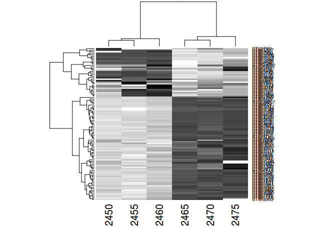

```r
#NM: arrays 53_01_12559679_2450/55/60, SM: arrays 53_16_12555026_2465/70/75
#note the key pattern (genes are either up-regulated in NM or in SM) but also the
#variability in M values of the three replicate arrays

top100.2 <- top100[order(top100$Clone_name),]
top100clones <- top100.2$Clone_name
MA.q.a.2 <- MA.q.a [which(MA.q.a$genes$Clone_name%in%top100clones),]
heat <- as.matrix(MA.q.a.2$M)
row.names(heat) <- MA.q.a.2$genes$Clone_name

jpeg("top100_heatmap.jpg", width=1200, height=1200)
heatmap(heat,col=grey(250:0/250))
dev.off()
```

# 4 Questions

> **Q1.1.** In your own words, describe what information can be gained from a volcano plot and a Venn diagram.

> **Q1.2.** What can you infer in terms of numbers of differentially expressed in M. sexta-induced S. nigrum and N. attenuata plants respectively when compared with control plants? For your answer, compare volcano plots for comparisons 1 and 2 and consider Venn diagrams of up- and down-regulated genes.

> **Q1.3.** Compare your Venn diagram with the one from the original publication (Schmidt et al. 2005, figure 5). What is the major difference between the two Venn diagrams? (The results vary due to differences in analysis parameters.)

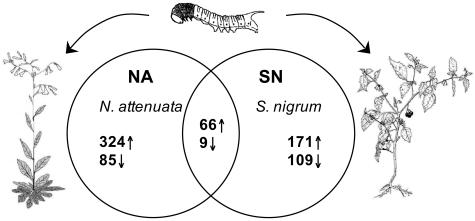

**Figure 5:** Copied from Schmidt et al. 2005. The Venn diagram shows commonly and specifically up- and down-regulated genes in *N. attenuata* and *S. nigrum* in response to herbivory by *M. sexta*.

> **Q1.4.** How many genes are more highly expressed in M. sexta-induced N. attenuata when compared with M. sexta-induced S. nigrum and vice versa (see results for comparison 3)?

> **Q1.5.** In your own words, describe what information can be gained from an MA plot. Then, compare the MA plots before and after within-array normalization and briefly describe the effect within-array normalization had on the data.

> **Q1.6.** In your own words, describe what information can be gained from a box plot. Then, compare the box plots for the log red intensities before and after between-array normalization (the data for the log green intensities are very similar) and briefly describe the effect between-array normalization had on the data.

> **Q1.7.** In your own words, describe why heatmaps are a useful means to graphically depict microarray results (or results of multidimensional data sets in general).

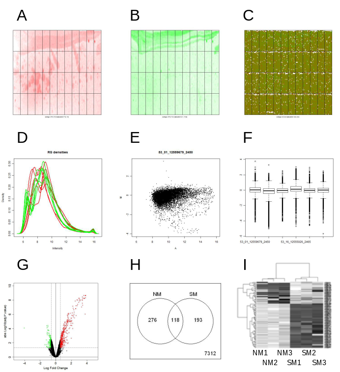

**Figure 6:** Examples of commonly used graphs to visualise microarray data. All graphs were taken from this case study. **A: Spatial plot** of red background intensities of array one. **B: Spatial plot** of green background intensities of array one. **C: Spatial plot** of non-normalized log fold ratios (M) of array one. **D: Density plot** – Density distribution of the background corrected raw densities of the six red and green channels. E MA plot – M values plotted versus A values of array one after within-array normalization. **F: Box-plot** – M value distributions of all six arrays after within array normalization. **G: Volcano plot** – Log p-value plotted against log fold ratio (M) of genes differentially expressed in response to one day of M. sexta feeding on N. attenuata. **H: Venn diagram** showing numbers of commonly and specifically up-regulated genes in M. sexta-indcued N. attenuata and S. nigrum plants. **I: Heatmap** of the 100 top differentially expressed genes in the three replicate NM and SM arrays.

# 5 Terms and concepts relevant to this microarray case study

# 6 References

*Draghici S* (2003) Data Analysis Tools for DNA Microarrays. Chapman & Hall/CRC, Boca Raton.

*Fowler JH, Narvaez-Vasquez J, Aromdee DN, Pautot V, Holzer FM, Walling LL* (2009) Leucine aminopeptidase regulates defense and wound signaling in tomato downstream of jasmonic acid. Plant Cell 21, 1239-1251.

*Hard M, Merker H, Schmidt DD, Baldwin IT* (2008) Optimized virus-induced gene silencing in Solanum nigrum reveals the defensive function of leucine aminopeptidase against herbivores and the shortcomings of empty vector controls. New Phytol 179, 356-365.

*Matsui M, Fowler JH, Walling LL* (2006) Leucine aminopeptidases: diversity in structure and function. Biological Chemistry 387, 1535-1544.

*Ritchie ME, Silver J, Oshlack A, et al.* (2007) A comparison of background correction methods for two-colour microarrays. Bioinformatics 23, 2700-2707.

*Schmidt DD, Voelckel C, Hartl M, Schmidt S, Baldwin IT* (2005) Specificity in ecological interactions. Attack from the same lepidopteran herbivore results in species-specific transcriptional responses in two solanaceous host plants. Plant Physiology 138, 1763-1773.

*Smyth GK* (2005) Limma: linear models for microarray data In: Bioinformatics and Computational Biology Solutions using R and Bioconductor (eds. Gentleman R, Carey V, Dudoit S, Irizarry R, Huber W), pp. 397-420 Springer, New York.

*Stekel D* (2003) Microarray Bioinformatics. Cambridge University Press, Cambridge.

*Team RDC* (2008) R: A language and environment for statistical computing R Foundation for Statistical Computing Vienna, Austria.